# Análisis de los casos de anemia en infantes y mujeres de 12 a 49 años en el Perú en el año 2022

Colque Ordoñez, Patrick Fabrizio

Rejas Albujar, Alejandro David

Escobar Núñez, Alejandro Ismael

## 1. Introducción

### Relevancia

- La anemia es un problema de salud pública de gran relevancia en nuestro país.
- La falta de hemoglobina en la sangre puede tener consecuencias graves, especialmente en niños y madres.
- Comprender la prevalencia y severidad de la anemia en estos grupos es esencial para abordar adecuadamente este problema de salud en el país.

### Objetivos

- Describir los casos de anemia y su severidad en niños y mujeres en el Perú en el año 2022.
- Analizar el índice de anemia en las diversas regiones del Perú en el año 2022.
- Describir las características sociales de los grupos vulnerables (niños y mujeres) a la anemia en el Perú en el año 2022.

### Contexto

- En el mes de mayo del año 2022, se llevó a cabo en nuestro país la Encuesta Demográfica y de Salud Familiar.
- Tres cuestionarios diseñados específicamente: uno dirigido a todos los miembros de cada hogar, otro enfocado en mujeres cuyas edades se encontraban en el rango de 12 a 49 años, y un tercero destinado a individuos de 15 años o más.
- Se solicitó a los residentes de los hogares su participación en una evaluación destinada a conocer sus niveles de hemoglobina en la sangre, a la que podían optar por unirse o no.

## 2. Datos

- Los datos para este estudio se obtuvieron a partir de la Encuesta Demográfica y de Salud Familiar realizada en mayo de 2022 en el Perú.
- Información sobre las características de los hogares y sus integrantes.
- Información relevante y detallada para nuestros objetivos de investigación.

### 2.1 Población objetivo, muestra y muestreo

- **Población:** Miembros de los hogares de la Encuesta Demográfica y de Salud Familiar.
- **Muestra:** Mujeres de 12 a 49 años de edad y niños o niñas menores de 5 años residentes de los hogares particulares recogidos por la encuesta.
- **Muestreo:** Probabilístico por conglomerados.

### 2.2 Tablas

- **Tabla RECH0:** Características del hogar
- **Tabla RECH5:** Peso y talla (anemia).
- **Tabla REC0111:** Datos básicos del MEF.
- **Tabla REC44:** Peso y talla (anemia).
- **Tabla RECH23:** Características del hogar de los participantes.

## 3. Análisis Descriptivo Univariado

### 3.1 Variables numéricas

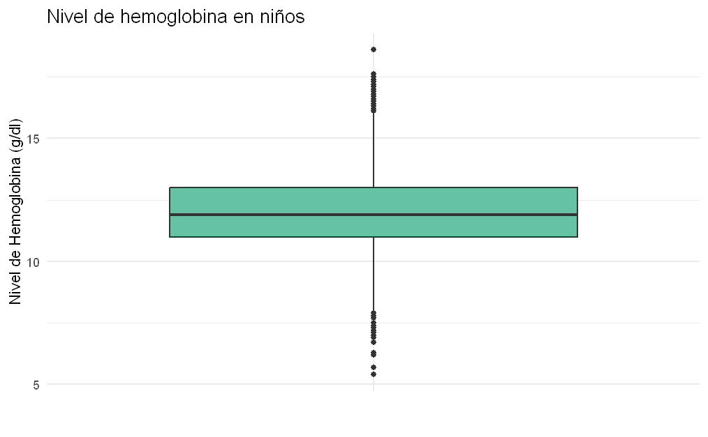

### 3.2 Variables categóricas

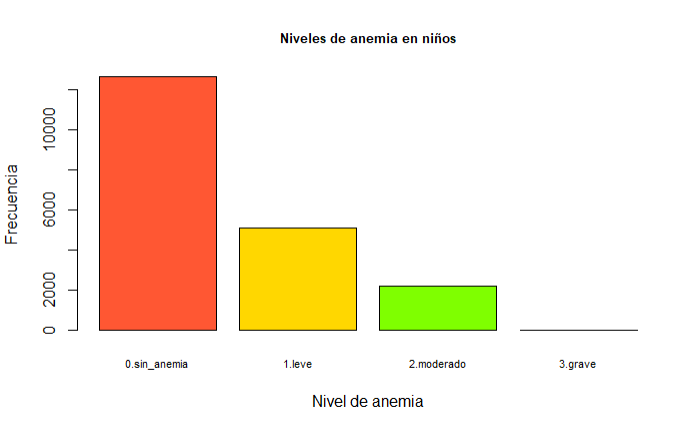

## 4. Análisis Descriptivo Bivariado o de Interacción

### 4.1 Gráficas relacionadas a los niños

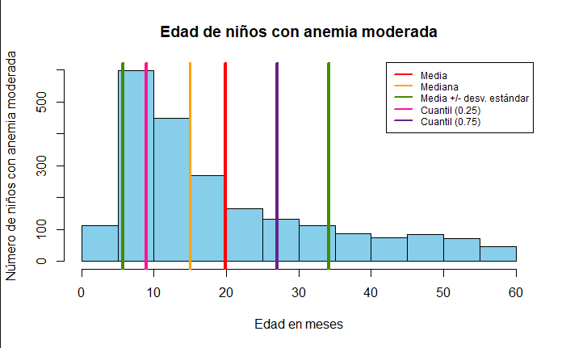

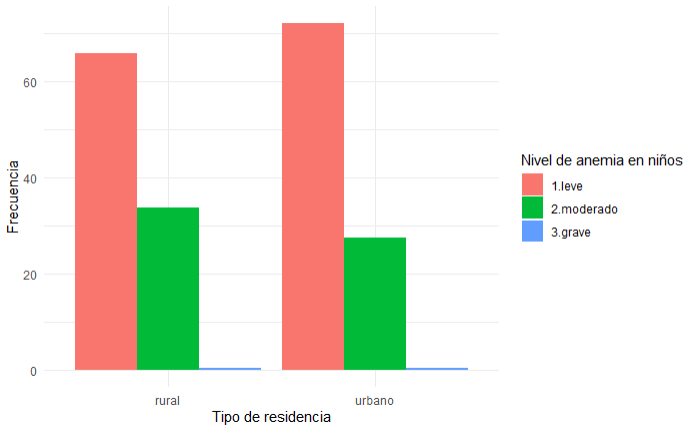

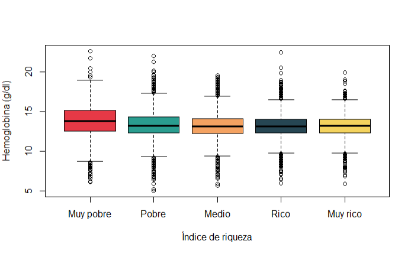

## 4. Análisis Descriptivo Bivariado o de Interacción

### 4.1 Regiones vs. nivel de anemia

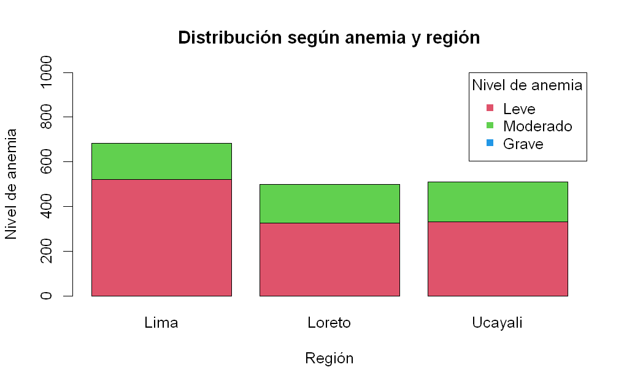

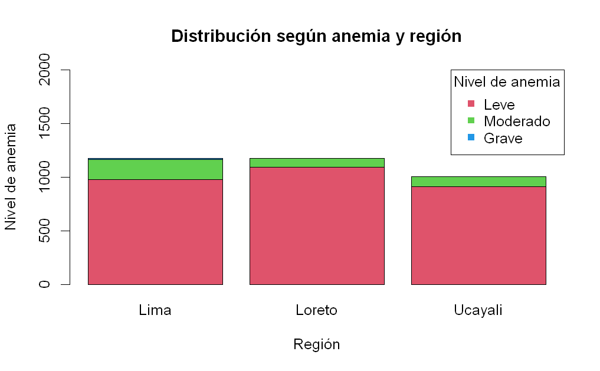

## 6. Probabilidad Empírica - Índice de Riqueza

Utilizamos la variable Índice de Riqueza e identificamos las probabilidades de sus eventos mediante la siguiente fórmula:

$$P(x) = \dfrac{f(x)} {n}$$

`prob_riqueza <- table(RECH23$indice_riqueza) / sum(table(RECH23$indice_riqueza))`

Graficamos `prob_riqueza`:

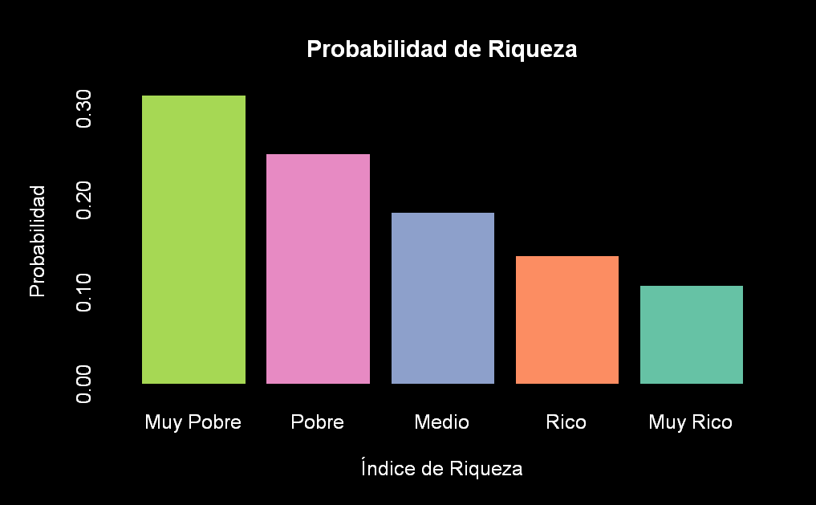

## 7. Probabilidad Condicional - Eventos Dependientes

Seleccionamos dos eventos dependientes:

- $A1$: Seleccionar una mujer de la muestra que esté embarazada.
- $A2$: Seleccionar una mujer de la muestra que no esté embarazada.

Demostramos su dependencia:

`'A1_&_A2' <- nrow(filter(RECH5, is_embarazada == "embarazada" & is_embarazada == "no embarazada")) = 0`

$$P(A1 \cap A2) = 0$$

Definimos la condición:

- $B$: La mujer seleccionada tiene como mayor nivel educativo alcanzado la secundaria.

Calculamos las probabilidades utilizando el teorema de Bayes:

$$P(A \mid B) = \frac{P(B \mid A) \times P(A)}{P(B)}$$

$$P(A1 \mid B) = 0.02863548$$

`prob_A1_dado_B <- prob_B_dado_A1_x_prob_A1 / B`

$$P(A2 \mid B) = 0.9713645$$

`prob_A2_dado_B <- prob_b_dado_a2_x_prob_a2/B`

`prob_A2_dado_B = 0.9713645`

## 8. Probabilidad Condicional - Eventos Independientes

Seleccionamos dos eventos independientes:

- $B1$: Seleccionar un niño que tenga anemia dado que vive en un lugar urbano.
- $B2$: Seleccionar un niño que tenga anemia dado que vive en un lugar rural.

Demostramos su independencia:

$$P(B1 \cap B2) = P(B1) \times P(B2)$$

`choose((3223 + 1232 + 14),1) * choose((1891 + 967 + 13), 1)/(choose(13570, 1)*choose(6385, 1) = 0.1480822`

`B1 * B2 = 0.1480822`

Dado que son independientes, se cumple lo siguiente:

$$P(B1 \mid B2) = B1$$

`prob_B2_dado_B1 <- B1_interseccion_B2 / B2`

`prob_B2_dado_B1 = 0.3293294`

`B1 = 0.3293294`

$$P(B2 \mid B1) = B2$$

`prob_B1_dado_B2 <- B1_interseccion_B2 / B1 = 0.449476`

`prob_B1_dado_B2 = 0.449476`

`B2 = 0.449476`

## 9. Variables Aleatorias Discretas - Número de madres con un determinado Nivel Educativo

Vamos a tomar el evento $S$, ‘Seleccionar a una madre que participó en la encuesta y su nivel educativo máximo alcanzado es secundaria’, como nuestro éxito.

$$P(S) = 0.65$$

$X$: Número de madres cuyo mayor nivel educativo alcanzado sea la secundaria en una muestra sin reemplazo de 100.

Vamos a utilizar el modelo hipergeométrico:

$$X\sim H(N, \; r, \; n)$$

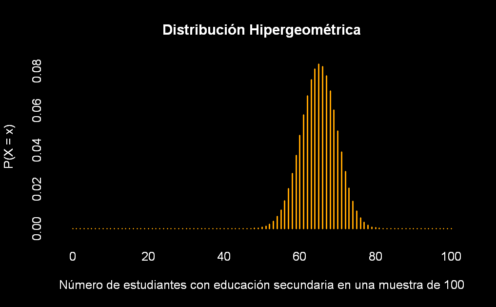

## 10. Variables Aleatorias Continuas - Hemoglobina ajustada en función de la latitud (g/dl)

$X$: Nivel de hemoglobina en g/dl de una madre encuestada.

Hallamos el tipo de distribución de nuestra variable aleatoria continua utilizando la librería `rriskDistributions`:

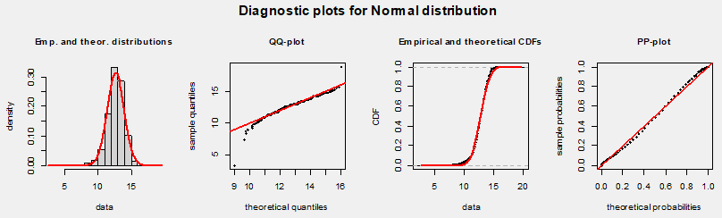

El tipo de distribución que más se ajusta a nuestra variable es la distribución normal:

$$X \sim N(\mu, \; \sigma^2 )$$

En $R$, los parámetros de una distribución normal son la **media** y la **desviación estándar**.

Gráfico de una distribución de probabilidad normal:

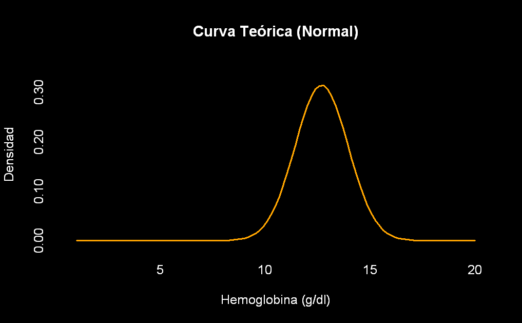

$$P(X < 12)$$

`pnorm(12, mu_h, sigma_h) = 0.2947574`

## 11. Cierre

El estudio de esta base de datos fue una experiencia muy enriquecedora y nos permitió explorar aplicar conceptos de la estadística de una manera muy práctica e intuitiva.

Con respecto al primer objetivo, podemos concluir lo siguiente:

Con respecto al segundo objetivo, podemos concluir lo siguiente:

Con respecto al tercer objetivo, podemos concluir lo siguiente:

- La dispersión del nivel de anemia con respecto al índice de riqueza no varía mucho.
- Los niños que viven en una residencia rural son más propensos a tener anemia moderada que los que viven en residencia urbana.